# MA7007 Week8 Model Selection

```r
#===========================
# The US Air Pollution Data
#===========================
library(gamlss)
data(usair)
```

```r
mod1 <- gamlss(y ~ ., data = usair, family = GA)
```

The drop1() and add1() functions are used to assess the significance of terms in the model by dropping or adding them.

```r
# drop1()

# drop1(mod1)

drop1(mod1, parallel="snow", ncpuss=4)
```

```
Single term deletions for
mu

Model:
y ~ x1 + x2 + x3 + x4 + x5 + x6
       Df    AIC     LRT  Pr(Chi)
<none>    319.16
x1      1 327.58 10.4245 0.001244 **
x2      1 326.92  9.7557 0.001788 **
x3      1 321.39  4.2299 0.039717 *
x4      1 324.08  6.9247 0.008501 **
x5      1 320.57  3.4141 0.064642 .
x6      1 317.16  0.0017 0.966960
---
Signif. codes:  0 ‘***’ 0.001 ‘**’ 0.01 ‘*’ 0.05 ‘.’ 0.1 ‘ ’ 1
```

```r
# add1()

# add1(mod1, scope = ~(x1 + x2 + x3 + x4 + x5 + x6)^2)

add1(mod1, scope = ~(x1 + x2 + x3 + x4 + x5 + x6)^2, parallel="snow", ncpuss=4)
```

```
Single term additions for
mu

Model:
y ~ x1 + x2 + x3 + x4 + x5 + x6
       Df    AIC     LRT   Pr(Chi)
<none>    319.16
x1:x2   1 320.09  1.0689 0.3012045
x1:x3   1 319.40  1.7626 0.1843028
x1:x4   1 320.60  0.5623 0.4533271
x1:x5   1 316.94  4.2226 0.0398901 *
x1:x6   1 320.93  0.2351 0.6277906
x2:x3   1 320.48  0.6786 0.4100846
x2:x4   1 319.75  1.4138 0.2344256
x2:x5   1 318.17  2.9873 0.0839194 .
x2:x6   1 321.13  0.0310 0.8603147
x3:x4   1 317.38  3.7783 0.0519200 .
x3:x5   1 320.19  0.9672 0.3253680
x3:x6   1 320.85  0.3061 0.5800599
x4:x5   1 307.07 14.0870 0.0001745 ***
x4:x6   1 320.33  0.8346 0.3609322
x5:x6   1 318.74  2.4188 0.1198894
---
Signif. codes:  0 ‘***’ 0.001 ‘**’ 0.01 ‘*’ 0.05 ‘.’ 0.1 ‘ ’ 1
```

The stepGAIC() function is used to perform stepwise model selection using the Generalized Akaike Information Criterion (GAIC). Different options are explored, such as parallelization, setting the k parameter, and specifying the scope of terms to be considered.

```r
# stepGAIC()

mod2 <- stepGAIC(mod1, parallel="snow", ncpuss=4)
```

```
Distribution parameter:  mu
Start:  AIC= 319.16
 y ~ x1 + x2 + x3 + x4 + x5 + x6

       Df    AIC
- x6    1 317.16
<none>    319.16
- x5    1 320.57
- x3    1 321.39
- x4    1 324.08
- x2    1 326.92
- x1    1 327.58

Step:  AIC= 317.16
 y ~ x1 + x2 + x3 + x4 + x5

       Df    AIC
<none>    317.16
- x3    1 319.39
- x4    1 322.48
- x5    1 324.14
- x2    1 324.92
- x1    1 336.11
```

```r
mod21 <- stepGAIC(mod1, k=length(usair$y))
```

```
Distribution parameter:  mu
Start:  AIC= 631.16
 y ~ x1 + x2 + x3 + x4 + x5 + x6

       Df    AIC
- x6    1 590.16
- x5    1 593.57
- x3    1 594.39
- x4    1 597.08
- x2    1 599.92
- x1    1 600.58
<none>    631.16

Step:  AIC= 590.16
 y ~ x1 + x2 + x3 + x4 + x5

       Df    AIC
- x3    1 553.39
- x4    1 556.48
- x5    1 558.14
- x2    1 558.92
- x1    1 570.11
<none>    590.16

Step:  AIC= 553.39
 y ~ x1 + x2 + x4 + x5

       Df    AIC
- x4    1 519.44
- x5    1 522.65
- x2    1 530.43
- x1    1 541.16
<none>    553.39

Step:  AIC= 519.44
 y ~ x1 + x2 + x5

       Df    AIC
- x5    1 484.78
- x2    1 491.11
- x1    1 500.28
<none>    519.44

Step:  AIC= 484.78
 y ~ x1 + x2

       Df    AIC
- x2    1 455.04
- x1    1 460.05
<none>    484.78

Step:  AIC= 455.04
 y ~ x1

       Df    AIC
- x1    1 431.71
<none>    455.04

Step:  AIC= 431.71
 y ~ 1
```

```r
mod3 <- stepGAIC(mod1, scope=list(lower=~1,
                                  upper=~(x1+x2+x3+x4+x5+x6)^2))
```

```
Distribution parameter:  mu
Start:  AIC= 319.16
 y ~ x1 + x2 + x3 + x4 + x5 + x6

        Df    AIC
+ x4:x5  1 307.07
+ x1:x5  1 316.94
- x6     1 317.16
+ x3:x4  1 317.38
+ x2:x5  1 318.17
+ x5:x6  1 318.74
<none>     319.16
+ x1:x3  1 319.40
+ x2:x4  1 319.75
+ x1:x2  1 320.09
+ x3:x5  1 320.19
+ x4:x6  1 320.33
+ x2:x3  1 320.48
- x5     1 320.57
+ x1:x4  1 320.60
+ x3:x6  1 320.85
+ x1:x6  1 320.93
+ x2:x6  1 321.13
- x3     1 321.39
- x4     1 324.08
- x2     1 326.92
- x1     1 327.58

Step:  AIC= 307.07
 y ~ x1 + x2 + x3 + x4 + x5 + x6 + x4:x5

        Df    AIC
+ x1:x6  1 300.94
+ x4:x6  1 301.65
+ x1:x4  1 302.09
- x6     1 305.12
+ x3:x5  1 306.94
<none>     307.07
+ x2:x5  1 307.78
+ x2:x4  1 307.94
```

[output cut: 153 more lines]

```
+ x1:x4  1 293.55
+ x1:x5  1 293.95
+ x2:x5  1 294.08
- x2:x6  1 294.19
+ x5:x6  1 294.54
+ x3:x5  1 294.55
+ x1:x2  1 294.71
+ x1:x3  1 294.72
- x1:x6  1 295.18
- x3:x6  1 296.41
- x2:x3  1 297.34
- x3:x4  1 300.27
- x2:x4  1 300.41
- x4:x6  1 307.60
- x4:x5  1 328.13
```

```r
mod2$anova
```

```
Stepwise Model Path
Analysis of Deviance Table

Initial
mu
 Model:
y ~ x1 + x2 + x3 + x4 + x5 + x6

Final
mu
 Model:
y ~ x1 + x2 + x3 + x4 + x5


  Step Df    Deviance Resid. Df Resid. Dev      AIC
1                            33   303.1602 319.1602
2 - x6  1 0.001715758        34   303.1619 317.1619
```

```r
mod21$anova
```

```
Stepwise Model Path
Analysis of Deviance Table

Initial
mu
 Model:
y ~ x1 + x2 + x3 + x4 + x5 + x6

Final
mu
 Model:
y ~ 1


  Step Df     Deviance Resid. Df Resid. Dev      AIC
1                             33   303.1602 631.1602
2 - x6  1  0.001715758        34   303.1619 590.1619
3 - x3  1  4.228188153        35   307.3901 553.3901
4 - x4  1  7.051270032        36   314.4413 519.4413
5 - x5  1  6.339657587        37   320.7810 484.7810
6 - x2  1 11.254434366        38   332.0354 455.0354
7 - x1  1 17.679186837        39   349.7146 431.7146
```

```r
mod4 <- stepGAIC(mod1, parameter="sigma",
                 scope=~x1+x2+x3+x4+x5+x6)
```

```
Distribution parameter:  sigma
Start:  AIC= 319.16
 ~1

       Df    AIC
+ x5    1 317.32
+ x4    1 317.34
+ x6    1 318.36
<none>    319.16
+ x1    1 319.29
+ x3    1 319.39
+ x2    1 320.60

Step:  AIC= 317.32
 ~x5

       Df    AIC
+ x1    1 314.21
+ x6    1 317.20
+ x3    1 317.21
<none>    317.32
+ x2    1 318.76
- x5    1 319.16
+ x4    1 319.42

Step:  AIC= 314.21
 ~x5 + x1

       Df    AIC
<none>    314.21
+ x3    1 314.57
+ x2    1 315.58
+ x6    1 315.59
+ x4    1 316.04
- x1    1 317.32
- x5    1 319.29
```

The GAIC() function is used to compare the fitted models based on their GAIC values.

```r
GAIC(mod1, mod2, mod21, mod3, mod4) # model selection
```

|  | df | AIC |
| --- | --- | --- |
| mod3 | 16 | 292.7225 |
| mod4 | 10 | 314.2083 |
| mod2 | 7 | 317.1619 |
| mod1 | 8 | 319.1602 |
| mod21 | 2 | 353.7146 |

The plot() and wp() functions are used for diagnostic plots and worm plots, respectively, for the selected models.

```
          Summary of the Quantile Residuals
                           mean   =  0.0009980663
                       variance   =  1.025189
               coef. of skewness  =  -0.543188
               coef. of kurtosis  =  3.558884
Filliben correlation coefficient  =  0.9720361
```

[figure not shown]

```r
## plot() and wp(): # diagnostics

plot(mod3)
```

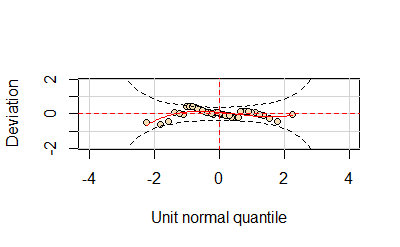

```r
wp(mod3)
```

The stepGAICAll.A() and stepGAICAll.B() functions are used for automated model selection, considering linear terms and smoothers.

```r
# stepGAICAll.A()

m1 <- gamlss(y~1, data=usair, famly=GA,
             trace=FALSE) # null model

m2 <- stepGAICAll.A(m1, scope=list(lower=~1,
                                   upper=~x1+x2+x3+x4+x5+x6))# linear terms

m3 <- stepGAICAll.A(m1, scope=list(lower=~1,
                                   upper=~pb(x1)+pb(x2)+pb(x3)+pb(x4)+pb(x5)
                                   +pb(x6)), k=log(41)) # smoothers

# stepGAICAll.B()
m4<- stepGAICAll.B(m1, scope=list(lower=~1,
                                  upper=~x1+x2+x3+x4+x5+x6),
                   k=log(41))
```

```r
AIC(m1, m2, m3, m4)

plot(m4)
wp(m4)
```

[output not shown]

## AIDS

```r
#======================================================
# The AIDS data cases in the U.K. from January 1983
# to March 1994
# y : number of quarterly aids cases in England & Wales
# x : time in quarters from January 1983
# qrt : a factor for the quarterly seasonal effect
#======================================================

library(gamlss)

data(aids)
```

The find.hyper() function is used to estimate the hyperparameters of the model using a grid search and the Global GAIC criterion.

```r
# Global GAIC: find.hyper()

mod1 <- quote(gamlss(y ~ cs(x, df = p[1]) + qrt,
                     family = NBI, data = aids,
                     trace = FALSE))

op <- find.hyper(model = mod1, par = c(3),
                 lower = c(1), steps = c(0.1), pen = 2.8)
```

Local likelihood estimation methods are explored, including local Maximum Likelihood (ML), local Generalized Cross-Validation (GCV), and local GAIC, using the pb() function for penalized B-splines.

```r
# Local ML

data(aids)
m1 <- gamlss(y~pb(x)+qrt, data=aids, family=NBI)

edf(m1)

# Local GCV

m2 <- gamlss(y~pb(x, method="GCV")+qrt, data=aids, family=NBI)

edf(m2)

# Local GAIC

m3 <- gamlss(y~pb(x, method="GAIC", k=2)+qrt, data=aids, family=NBI)
```

[output not shown]

The edf() function is used to obtain the effective degrees of freedom for the fitted models, and the GAIC() function is used again for model comparison.

```r
edf(m3)

GAIC(m1, m2, m3)
```

[output not shown]

```r
## plot () and wp()
plot(m3)

wp(m3)
```

[output not shown]